# IODS course project

### 3. Regression model

From the previous plot we noticed a high correlation between attitude and points. Let’s also pick learning strategic and surface dimensions as our explanatory variables as they had the next highest absolute correlations (0.146 and 0.144).

```r
model <- lm(points ~ attitude + stra + surf, data = lrn14)
summary(model)
```

```
##
## Call:
## lm(formula = points ~ attitude + stra + surf, data = lrn14)
##
## Residuals:
##      Min       1Q   Median       3Q      Max
## -17.1550  -3.4346   0.5156   3.6401  10.8952
##
## Coefficients:
##             Estimate Std. Error t value Pr(>|t|)
## (Intercept)  11.0171     3.6837   2.991  0.00322 **
## attitude      3.3952     0.5741   5.913 1.93e-08 ***
## stra          0.8531     0.5416   1.575  0.11716
## surf         -0.5861     0.8014  -0.731  0.46563
## ---
## Signif. codes:  0 '***' 0.001 '**' 0.01 '*' 0.05 '.' 0.1 ' ' 1
##
## Residual standard error: 5.296 on 162 degrees of freedom
## Multiple R-squared:  0.2074, Adjusted R-squared:  0.1927
## F-statistic: 14.13 on 3 and 162 DF,  p-value: 3.156e-08
```

The p-value PR(>|t|) is an indication if whether or not we can reject or accept a hypothesis - a predictior being not meaningful to our model. A lower p-value means that the variable is a good addition to a model. Strategy is pretty bad variable also as it’s still over 0.05 which is the standard way to test if a predictor is meaningful. Let’s first take away surface as it has the highest p-value and see the results.

```r
model <- lm(points ~ attitude + stra, data = lrn14)
summary(model)
```

```
##
## Call:
## lm(formula = points ~ attitude + stra, data = lrn14)
##
## Residuals:
##      Min       1Q   Median       3Q      Max
## -17.6436  -3.3113   0.5575   3.7928  10.9295
##
## Coefficients:
##             Estimate Std. Error t value Pr(>|t|)
## (Intercept)   8.9729     2.3959   3.745  0.00025 ***
## attitude      3.4658     0.5652   6.132 6.31e-09 ***
## stra          0.9137     0.5345   1.709  0.08927 .
## ---
## Signif. codes:  0 '***' 0.001 '**' 0.01 '*' 0.05 '.' 0.1 ' ' 1
##
## Residual standard error: 5.289 on 163 degrees of freedom
## Multiple R-squared:  0.2048, Adjusted R-squared:  0.1951
## F-statistic: 20.99 on 2 and 163 DF,  p-value: 7.734e-09
```

The model improved but p-value of strategic learning is still over 0.05 so let’s remove it.

```r
model <- lm(points ~ attitude, data = lrn14)
summary(model)
```

```
##
## Call:
## lm(formula = points ~ attitude, data = lrn14)
##
## Residuals:
##      Min       1Q   Median       3Q      Max
## -16.9763  -3.2119   0.4339   4.1534  10.6645
##
## Coefficients:
##             Estimate Std. Error t value Pr(>|t|)
## (Intercept)  11.6372     1.8303   6.358 1.95e-09 ***
## attitude      3.5255     0.5674   6.214 4.12e-09 ***
## ---
## Signif. codes:  0 '***' 0.001 '**' 0.01 '*' 0.05 '.' 0.1 ' ' 1
##
## Residual standard error: 5.32 on 164 degrees of freedom
## Multiple R-squared:  0.1906, Adjusted R-squared:  0.1856
## F-statistic: 38.61 on 1 and 164 DF,  p-value: 4.119e-09
```

### 4. Summary of model and R-squared model

```r
final_model <- lm(points ~ attitude, data = lrn14)
summary(model)
```

```
##
## Call:
## lm(formula = points ~ attitude, data = lrn14)
##
## Residuals:
##      Min       1Q   Median       3Q      Max
## -16.9763  -3.2119   0.4339   4.1534  10.6645
##
## Coefficients:
##             Estimate Std. Error t value Pr(>|t|)
## (Intercept)  11.6372     1.8303   6.358 1.95e-09 ***
## attitude      3.5255     0.5674   6.214 4.12e-09 ***
## ---
## Signif. codes:  0 '***' 0.001 '**' 0.01 '*' 0.05 '.' 0.1 ' ' 1
##
## Residual standard error: 5.32 on 164 degrees of freedom
## Multiple R-squared:  0.1906, Adjusted R-squared:  0.1856
## F-statistic: 38.61 on 1 and 164 DF,  p-value: 4.119e-09
```

The last 3 rows of code refers to so called R-squared model. Basically it’s a way to test the model. The R-squared measure is defined by the proportion of total variability by the model. To put it simply: models that poorly fit the data have a value close to 0 (0%) and in this model’s case the value is 0.1906 so the model explains 19.06% of the total variability. The adjusted value refers to a modified version of R-squared that adjusts for non-significant predictors in the model. It’s good for determining whether additional input variables are adding to the model (if such exists) - a higher adjusted R-squared value indicates tahat additional input variables are adding value.

### 5. Diagnostic plots

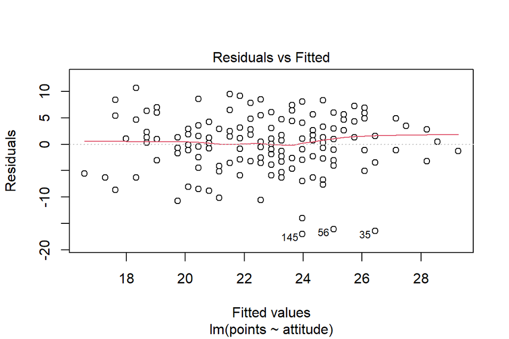

```r
plot(final_model, 1)
```

The residuals vs fitted values plot is used to detect non-linearity, unequal error variances and outliers. Overall the fitted model is an example of a well-behaved plot in which the residuals are around the 0 line and the residuals form a horizontal band around the 0 line. It seems that the fitted model is fairly appropriate for the data.

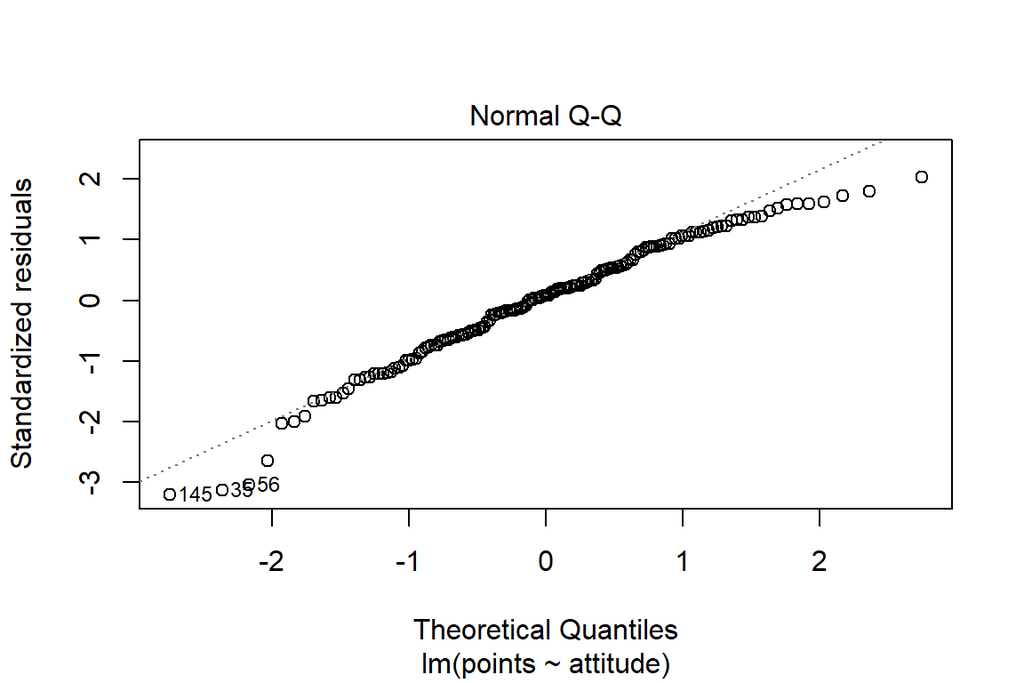

```r
plot(final_model, 2)
```

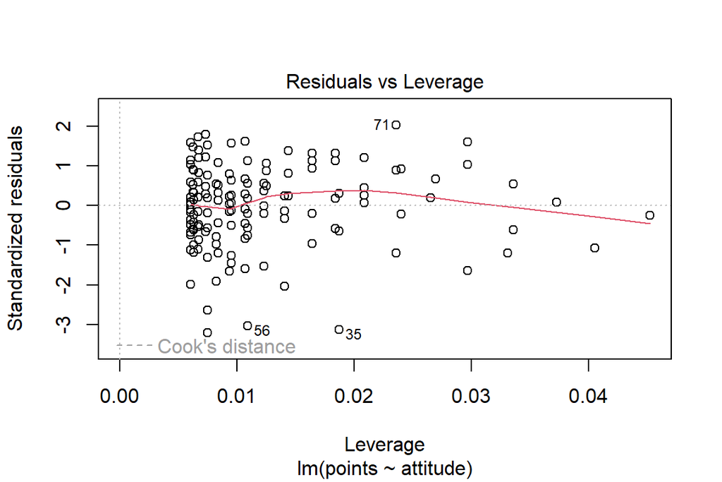

```r
plot(final_model, 5)
```

Residuals vs leverage plot allows us to identify influential observations in our model. No data point falls out of the Cook’s distance so there are no influential points in our model and the points are fairly evenly distributed around the 0-line. This tells us that the points are approximated fairly well.

# Assignment 3: Logistic Regression

```r
date()
```

```
## [1] "Mon Dec 12 23:11:02 2022"
```

## Data wrangling exercise

This time we joined two datasets together by their unique identifiers. I found the exercise useful though the wording ‘duplicates’ in the assignment kind of messed with my head since the ‘duplicates’ were actually different courses (portugal and math) which are unique values. As no output was needed in the course diary you can check the results of the data wrangling exercise [my data folder in the repo](https://github.com/jmlankinen/IODS-project/tree/master/data) if you wish to do so.

## Analysis

The purpose of this analysis is to study the relationships between high/low alcohol consumption and variables within a dataset.

### 1. Reading the data

```r
library(tidyverse)
library(GGally)
alc <- read.table("https://raw.githubusercontent.com/KimmoVehkalahti/Helsinki-Open-Data-Science/master/datasets/alc.csv", sep=",", header=TRUE)
glimpse(alc)
```

```
## Rows: 370
## Columns: 35
## $ school     <chr> "GP", "GP", "GP", "GP", "GP", "GP", "GP", "GP", "GP", "GP",…
## $ sex        <chr> "F", "F", "F", "F", "F", "M", "M", "F", "M", "M", "F", "F",…
## $ age        <int> 18, 17, 15, 15, 16, 16, 16, 17, 15, 15, 15, 15, 15, 15, 15,…
## $ address    <chr> "U", "U", "U", "U", "U", "U", "U", "U", "U", "U", "U", "U",…
## $ famsize    <chr> "GT3", "GT3", "LE3", "GT3", "GT3", "LE3", "LE3", "GT3", "LE…
## $ Pstatus    <chr> "A", "T", "T", "T", "T", "T", "T", "A", "A", "T", "T", "T",…
## $ Medu       <int> 4, 1, 1, 4, 3, 4, 2, 4, 3, 3, 4, 2, 4, 4, 2, 4, 4, 3, 3, 4,…
## $ Fedu       <int> 4, 1, 1, 2, 3, 3, 2, 4, 2, 4, 4, 1, 4, 3, 2, 4, 4, 3, 2, 3,…
## $ Mjob       <chr> "at_home", "at_home", "at_home", "health", "other", "servic…
## $ Fjob       <chr> "teacher", "other", "other", "services", "other", "other", …
## $ reason     <chr> "course", "course", "other", "home", "home", "reputation", …
## $ guardian   <chr> "mother", "father", "mother", "mother", "father", "mother",…
## $ traveltime <int> 2, 1, 1, 1, 1, 1, 1, 2, 1, 1, 1, 3, 1, 2, 1, 1, 1, 3, 1, 1,…
```

[output cut: 22 more lines]

The data we look into this exercise is about student alcohol consumption and its’ affect to student performance. Glimpse() function gives us a sneak peek into the dataset. It has 35 variables/columns which are in the following forms: integer, character, double and logical. The csv file in hand has been modified based on the data set found [here](https://archive.ics.uci.edu/ml/datasets/Student+Performance). The data is from a survey which was initially done to two different courses and in this modified csv file we’ve taken answers by students which were in both courses. The following adjustments have been made to the joined data set:

- The variables not used for joining the two data have been combined by averaging (including the grade variables)
- ‘alc_use’ is the average of ‘Dalc’ and ‘Walc’
- ‘high_use’ is TRUE if ‘alc_use’ is higher than 2 and FALSE otherwise

### 2. Hypothesis

We’re tasked to pick four interesting variables in the data and present a hypothesis about their relationships with alcohol consumption.

1. Students who consume a lot of alcohol (high_use) score lower in test than students who don’t.
2. Students’ whose father have a higher education level are less likely to consume alcohol than those with lower education.
3. Outgoing students are more likely to consume more alcohol
4. Male students are more likely to consume more alcohol than female students.

### 3. Exploring hypotheses

With hypotheses chosen we’ll numerically and graphically explore the chosen variables with a fitting way.

#### Alcohol consumption and test scores

```r
alc %>% group_by(high_use) %>% summarise(count = n(), median_grade = median(G3), mean_grade = mean(G3), Quartile11 = quantile(G3)[2], Quartile3 = quantile(G3)[4])
```

```
## # A tibble: 2 × 6
##   high_use count median_grade mean_grade Quartile11 Quartile3
##   <lgl>    <int>        <int>      <dbl>      <dbl>     <dbl>
## 1 FALSE      259           12       11.8         10        14
## 2 TRUE       111           11       10.9         10        12
```

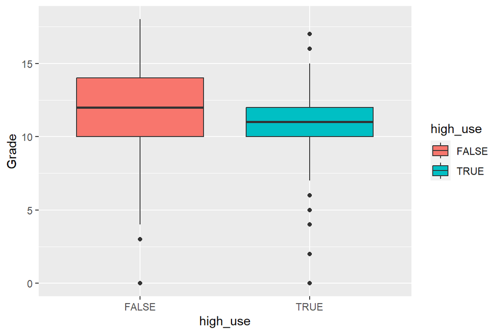

```r
g1 <- ggplot(alc, aes(x = high_use, y = G3, fill=high_use))
g1 + geom_boxplot() + ylab("Grade")
```

In the dataset there were 111 cases of high use alcohol (TRUE) consumers and 259 with less than 2 score of alcohol usage (FALSE). As expected high use of alcohol seems to have a negative effect on final test scores as the mean score is roughly 1 point less than the counterpart. High usage boxplot Q3 line is at the level of lower usage plot’s median. It’s also very tightly packed with 1st quartile & 3rd quartile being in the range of 10-12 compared to lower usage’s 10-14.

#### Father’s education’s affect on student’s alcohol consumption

```r
alc %>% group_by(Fedu, high_use) %>% summarise(count = n())
```

```
## # A tibble: 9 × 3
## # Groups:   Fedu [5]
##    Fedu high_use count
##   <int> <lgl>    <int>
## 1     0 FALSE        2
## 2     1 FALSE       49
## 3     1 TRUE        24
## 4     2 FALSE       75
## 5     2 TRUE        30
## 6     3 FALSE       70
## 7     3 TRUE        27
## 8     4 FALSE       63
## 9     4 TRUE        30
```

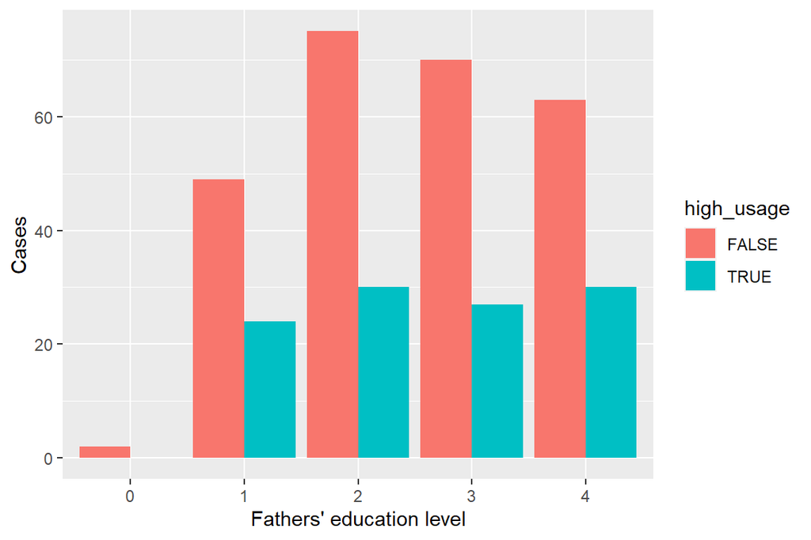

```r
#making a dataset based on summary
Fedudata <- data.frame(
  fedu = c("0", "0", "1", "1", "2", "2", "3", "3", "4", "4"),
  high_usage = c(FALSE, TRUE, FALSE, TRUE, FALSE, TRUE, FALSE, TRUE, FALSE, TRUE),
  count = c(2,0,49,24,75,30,70,27,63,30)
)

ggplot(Fedudata, aes(fill=high_usage, y=count, x=fedu)) + geom_bar(position="dodge", stat="identity") + xlab("Fathers' education level") + ylab("Cases")
```

We should exclude the 0 education level due it’s small sample size. It’s not evident from the bar graphs that father’s education level has a significant impact on student’s high usage of alcohol. In the first education level (primary school) the high usage is roughly the same as in the fourth education level (higher education). Interestingly education levels 2-3 seem to have a slightly smaller proportion of high usage alcohol consumers than in education levels 1 and 4. Out of interest I checked the effect on male students specifically and found a difference there:

```r
xtabs(~Fedu+high_use+sex, alc)
```

```
## , , sex = F
##
##     high_use
## Fedu FALSE TRUE
##    0     0    0
##    1    31   11
##    2    49    7
##    3    39   11
##    4    35   12
##
## , , sex = M
##
##     high_use
## Fedu FALSE TRUE
##    0     2    0
##    1    18   13
##    2    26   23
##    3    31   16
##    4    28   18
```

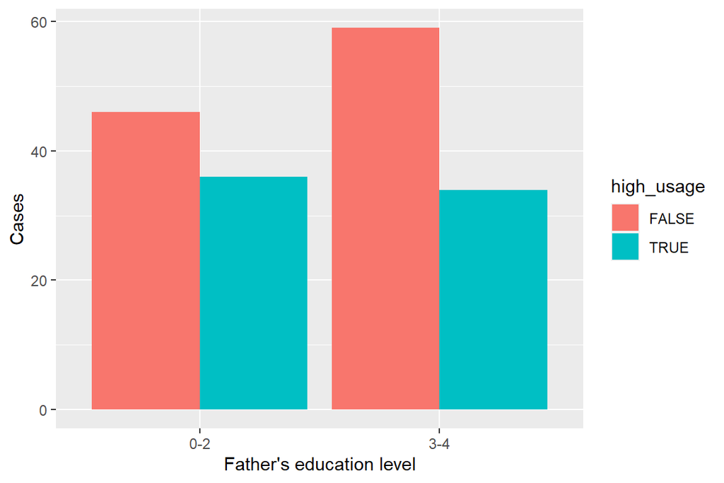

```r
#making a dataset based on summary of male students with father's grouped education levels 0-2 and 3-4
Fedudata <- data.frame(
  fedu = c("0-2", "0-2", "3-4", "3-4"),
  high_usage = c(FALSE, TRUE, FALSE, TRUE),
  count = c(46,36,59,34)
)

ggplot(Fedudata, aes(fill=high_usage, y=count, x=fedu)) + geom_bar(position="dodge", stat="identity") + xlab("Father's education level") + ylab("Cases")
```

Seems like father’s low education level increases the proportion of high usage alcohol consumers in male students.

#### Outgoing students consume more alcohol

```r
alc %>% group_by(goout, high_use) %>% summarise(count = n())
```

```
## # A tibble: 10 × 3
## # Groups:   goout [5]
##    goout high_use count
##    <int> <lgl>    <int>
##  1     1 FALSE       19
##  2     1 TRUE         3
##  3     2 FALSE       82
##  4     2 TRUE        15
##  5     3 FALSE       97
##  6     3 TRUE        23
##  7     4 FALSE       40
##  8     4 TRUE        38
##  9     5 FALSE       21
## 10     5 TRUE        32
```

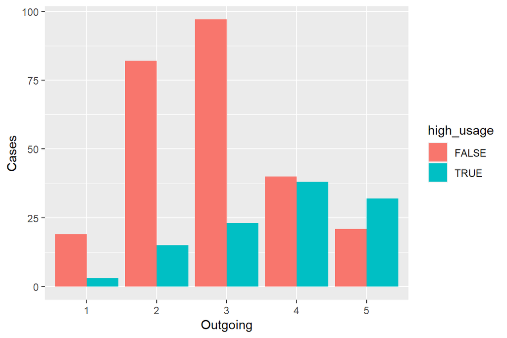

```r
#making a dataset based on summary
gooutdata <- data.frame(
  goout = c("1", "1", "2", "2", "3", "3", "4", "4", "5", "5"),
  high_usage = c(FALSE, TRUE, FALSE, TRUE, FALSE, TRUE, FALSE, TRUE, FALSE, TRUE),
  count = c(19,3,82,15,97,23,40,38,21,32)
)

ggplot(gooutdata, aes(fill=high_usage, y=count, x=goout)) + geom_bar(position="dodge", stat="identity") + xlab("Outgoing") + ylab("Cases")
```

Again we can see the hypothesis was accurate. In the outgoing levels of 1-3 (very low to moderate) the gap between high usage and low usage is noticeable. At Outgoing level 4 questionnaires are roughly split and the most outgoing students are more likely to be high usage consumers than low usage.

#### Alcohol consumption male vs female

```r
xtabs(~alc_use+sex, alc)
```

```
##        sex
## alc_use  F  M
##     1   87 53
##     1.5 41 22
##     2   26 30
##     2.5 25 16
##     3   11 21
##     3.5  3 14
##     4    1  8
##     4.5  0  3
##     5    1  8
```

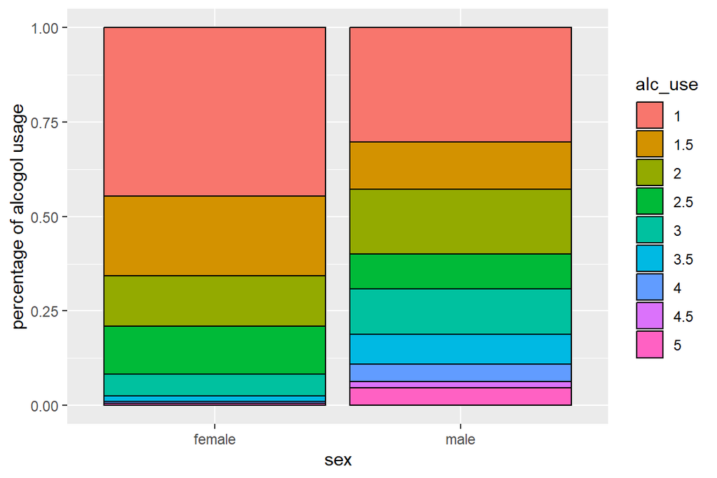

```r
#making a dataset based on xtabs
alc_use_data <- data.frame(
  alc_use = c("1", "1.5", "2", "2.5", "3", "3.5", "4", "4.5", "5", "1", "1.5", "2", "2.5", "3", "3.5", "4", "4.5", "5"),
  sex = c("male", "male", "male", "male", "male", "male", "male", "male", "male", "female", "female", "female", "female", "female", "female", "female", "female", "female"),
  count = c(53, 22, 30, 16, 21, 14, 8, 3, 8, 87, 41, 26, 25, 11, 3, 1, 0, 1)
)
#plotting the dataset
ggplot(alc_use_data, aes(fill=alc_use, y=count, x=sex)) + geom_bar(position="fill", stat="identity", colour="black") + xlab("sex") + ylab("percentage of alcogol usage")
```

Here we’ve plotted the alcolohol usage (1-5) as percentages of female and male students. Out of interest I specifically plotted the whole spectrum of usage (1-5) rather than the low/high usage. We can see from the bar graph that for females the low alcohol usage values from 1-2 correspond around 80% of the female students where as 1-2 corresponds 60% of male students. It’s safe to say that male students are more likely to consume high amounts of alcohol based on the graphs.

### 4. Logistic regression model

As instructed in the assignment we’ll use the variables used in hypotheses: G3 (final grade), Fedu (father’s education level), goout (‘outgoingness’ of student) & sex.

```r
# fitting the model & showing the summary
model <- glm(high_use ~ G3+Fedu+goout+sex, data = alc, family = "binomial")
summary(model)
```

```
##
## Call:
## glm(formula = high_use ~ G3 + Fedu + goout + sex, family = "binomial",
##     data = alc)
##
## Deviance Residuals:
##     Min       1Q   Median       3Q      Max
## -1.7543  -0.8370  -0.5729   0.8470   2.4756
##
## Coefficients:
##             Estimate Std. Error z value Pr(>|z|)
## (Intercept) -3.11758    0.69387  -4.493 7.02e-06 ***
## G3          -0.05695    0.03971  -1.434 0.151543
## Fedu         0.01864    0.11768   0.158 0.874114
## goout        0.72848    0.12015   6.063 1.33e-09 ***
## sexM         0.92443    0.25155   3.675 0.000238 ***
## ---
## Signif. codes:  0 '***' 0.001 '**' 0.01 '*' 0.05 '.' 0.1 ' ' 1
##
## (Dispersion parameter for binomial family taken to be 1)
##
##     Null deviance: 452.04  on 369  degrees of freedom
## Residual deviance: 386.86  on 365  degrees of freedom
## AIC: 396.86
##
## Number of Fisher Scoring iterations: 4
```

```r
# coefficients as odds ratios
odds_ratios <- coef(model) %>% exp

# confidence intervals
ci <- confint(model)
cbind(odds_ratios, ci)
```

```
##             odds_ratios      2.5 %      97.5 %
## (Intercept)  0.04426403 -4.5230245 -1.79503224
## G3           0.94464549 -0.1353284  0.02081591
## Fedu         1.01881957 -0.2121214  0.25031565
## goout        2.07192893  0.4991020  0.97114863
## sexM         2.52041925  0.4362474  1.42438709
```

#### Interpreting the model

Based on the estimates all the variables except for final grade can be considered as risk factors. Final grade is the only protective factor in the model though it’s non-significant as previously mentioned.

#### Predictive power of the model

```r
#dropping Fedu and G3 from the moodel
model2 <- glm(high_use ~ goout+sex, data = alc, family = "binomial")

#mutating the original table with model's predictions
alc <- mutate(alc, probability = predict(model2, type = "response"))
alc <- mutate(alc, prediction = probability > 0.5)
#showing the last 10 rows
select(alc, goout, sex, high_use, probability, prediction) %>% tail(10)
```

```
##     goout sex high_use probability prediction
## 361     3   M    FALSE  0.34999869      FALSE
## 362     2   M    FALSE  0.20151317      FALSE
## 363     3   M     TRUE  0.34999869      FALSE
## 364     3   F    FALSE  0.17569180      FALSE
## 365     3   F    FALSE  0.17569180      FALSE
## 366     2   F    FALSE  0.09082261      FALSE
## 367     4   F    FALSE  0.31259947      FALSE
## 368     1   F    FALSE  0.04472568      FALSE
## 369     5   M     TRUE  0.71024877       TRUE
## 370     1   M     TRUE  0.10577129      FALSE
```

If probability is over 0.5 then the model predicts that alcohol consumption is high (TRUE). Let’s visualize the actual values and predictions

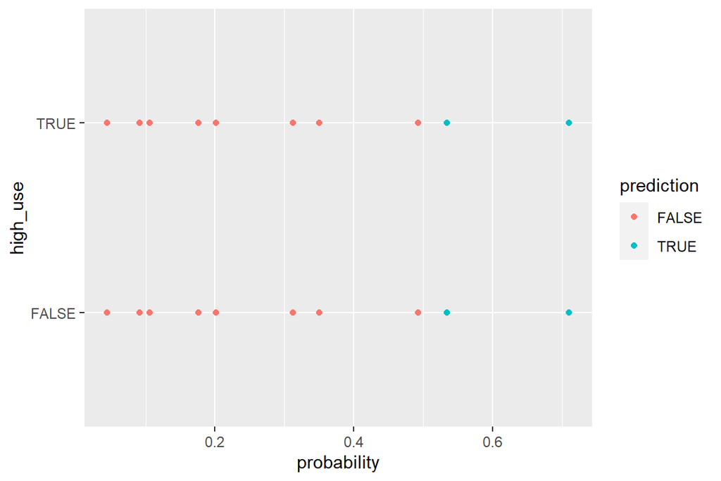

```r
#plotting the actual values vs predictions
ggplot(alc, aes(x = probability, y = high_use, col = prediction)) + geom_point()
```

```r
#tabulating target variable vs prediction
table(high_use = alc$high_use, prediction = alc$prediction)
```

```
##         prediction
## high_use FALSE TRUE
##    FALSE   242   17
##    TRUE     62   49
```

```r
# tabulate the target variable versus the predictions with proportions
table(high_use = alc$high_use, prediction = alc$prediction) %>%  prop.table() %>%  addmargins()
```

```
##         prediction
## high_use      FALSE       TRUE        Sum
##    FALSE 0.65405405 0.04594595 0.70000000
##    TRUE  0.16756757 0.13243243 0.30000000
##    Sum   0.82162162 0.17837838 1.00000000
```

```r
#mean prediction error function
loss_func <- function(class, prob) {
  n_wrong <- abs(class - prob) > 0.5
  mean(n_wrong)
}

loss_func(class = alc$high_use, prob = alc$probability)
```

```
## [1] 0.2135135
```

We get 21.4% of the predictions wrong with training data. Overall the model has a pretty hard time predicting higher usag (only 49 predictions correct out of 111 actuals). This might be due to the model’s simplicity (only two variables) and because it’s using sex as variable which has only two values. This limits it quite significantly since it values sex quite heavily when predicting high usage. This can be seen actual values vs prediction graph - probabilities can only get 10 different values due to the variables (sex has two and goout had five).

For future modeling purposes it would be wise to make the model a bit more complex by adding and look into what values variables can get so that you can ‘catch’ the full spectrum of predictions with the model as this one is lacking. Oh well, it was truly a learning experience and I hope you got something out of this too.

# Assignment 4: Clustering and classification

## Analysis

This week we delved into clustering and classification. Clustering means that some of the observations are close to each other than some other points. In other words the data points aren’t comprised of a homogeneous sample but they’re somehow clustered.

### 1. Overview of Boston dataset

This week’s dataset is ‘Boston’ dataset from the MASS library. The dataset has 506 rows and 14 columns/variables in which each row represents a suburb of Boston. The dataframe contains various statistics of each areas’ people, tax rates, crime rates, proportion of business acres etc. Description of each variable can be found [here](https://stat.ethz.ch/R-manual/R-devel/library/MASS/html/Boston.html).

```r
# Loading MASS for the dataset
library(MASS)
```

```r
library(tidyverse)
library(ggplot2)
library(GGally)

# load the data
data("Boston")

# explore the dataset
str(Boston)
```

```
## 'data.frame':    506 obs. of  14 variables:
##  $ crim   : num  0.00632 0.02731 0.02729 0.03237 0.06905 ...
##  $ zn     : num  18 0 0 0 0 0 12.5 12.5 12.5 12.5 ...
##  $ indus  : num  2.31 7.07 7.07 2.18 2.18 2.18 7.87 7.87 7.87 7.87 ...
##  $ chas   : int  0 0 0 0 0 0 0 0 0 0 ...
##  $ nox    : num  0.538 0.469 0.469 0.458 0.458 0.458 0.524 0.524 0.524 0.524 ...
##  $ rm     : num  6.58 6.42 7.18 7 7.15 ...
##  $ age    : num  65.2 78.9 61.1 45.8 54.2 58.7 66.6 96.1 100 85.9 ...
##  $ dis    : num  4.09 4.97 4.97 6.06 6.06 ...
##  $ rad    : int  1 2 2 3 3 3 5 5 5 5 ...
##  $ tax    : num  296 242 242 222 222 222 311 311 311 311 ...
##  $ ptratio: num  15.3 17.8 17.8 18.7 18.7 18.7 15.2 15.2 15.2 15.2 ...
##  $ black  : num  397 397 393 395 397 ...
##  $ lstat  : num  4.98 9.14 4.03 2.94 5.33 ...
##  $ medv   : num  24 21.6 34.7 33.4 36.2 28.7 22.9 27.1 16.5 18.9 ...
```

```r
summary(Boston)
```

```
##       crim                zn             indus            chas
##  Min.   : 0.00632   Min.   :  0.00   Min.   : 0.46   Min.   :0.00000
##  1st Qu.: 0.08205   1st Qu.:  0.00   1st Qu.: 5.19   1st Qu.:0.00000
##  Median : 0.25651   Median :  0.00   Median : 9.69   Median :0.00000
##  Mean   : 3.61352   Mean   : 11.36   Mean   :11.14   Mean   :0.06917
##  3rd Qu.: 3.67708   3rd Qu.: 12.50   3rd Qu.:18.10   3rd Qu.:0.00000
##  Max.   :88.97620   Max.   :100.00   Max.   :27.74   Max.   :1.00000
##       nox               rm             age              dis
##  Min.   :0.3850   Min.   :3.561   Min.   :  2.90   Min.   : 1.130
##  1st Qu.:0.4490   1st Qu.:5.886   1st Qu.: 45.02   1st Qu.: 2.100
##  Median :0.5380   Median :6.208   Median : 77.50   Median : 3.207
##  Mean   :0.5547   Mean   :6.285   Mean   : 68.57   Mean   : 3.795
##  3rd Qu.:0.6240   3rd Qu.:6.623   3rd Qu.: 94.08   3rd Qu.: 5.188
##  Max.   :0.8710   Max.   :8.780   Max.   :100.00   Max.   :12.127
##       rad              tax           ptratio          black
##  Min.   : 1.000   Min.   :187.0   Min.   :12.60   Min.   :  0.32
##  1st Qu.: 4.000   1st Qu.:279.0   1st Qu.:17.40   1st Qu.:375.38
##  Median : 5.000   Median :330.0   Median :19.05   Median :391.44
##  Mean   : 9.549   Mean   :408.2   Mean   :18.46   Mean   :356.67
##  3rd Qu.:24.000   3rd Qu.:666.0   3rd Qu.:20.20   3rd Qu.:396.23
##  Max.   :24.000   Max.   :711.0   Max.   :22.00   Max.   :396.90
##      lstat            medv
##  Min.   : 1.73   Min.   : 5.00
##  1st Qu.: 6.95   1st Qu.:17.02
##  Median :11.36   Median :21.20
##  Mean   :12.65   Mean   :22.53
##  3rd Qu.:16.95   3rd Qu.:25.00
##  Max.   :37.97   Max.   :50.00
```

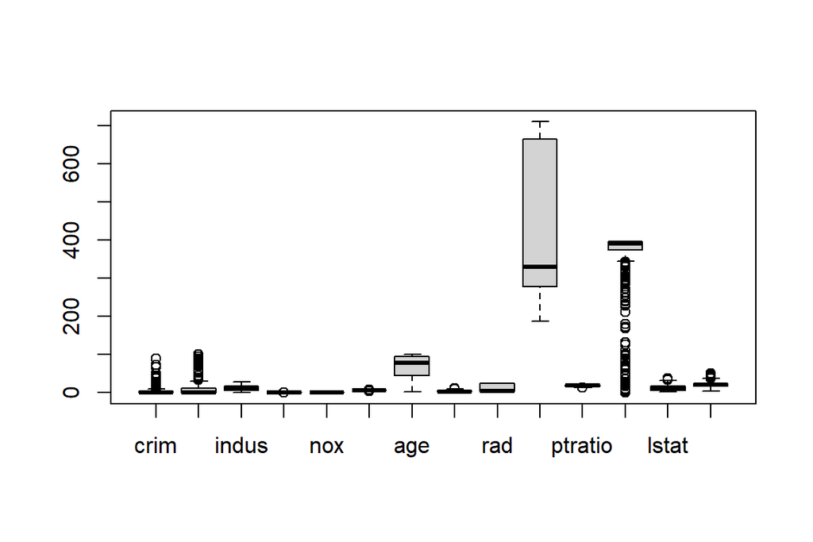

```r
# plot matrix of the variables
boxplot(Boston)
```

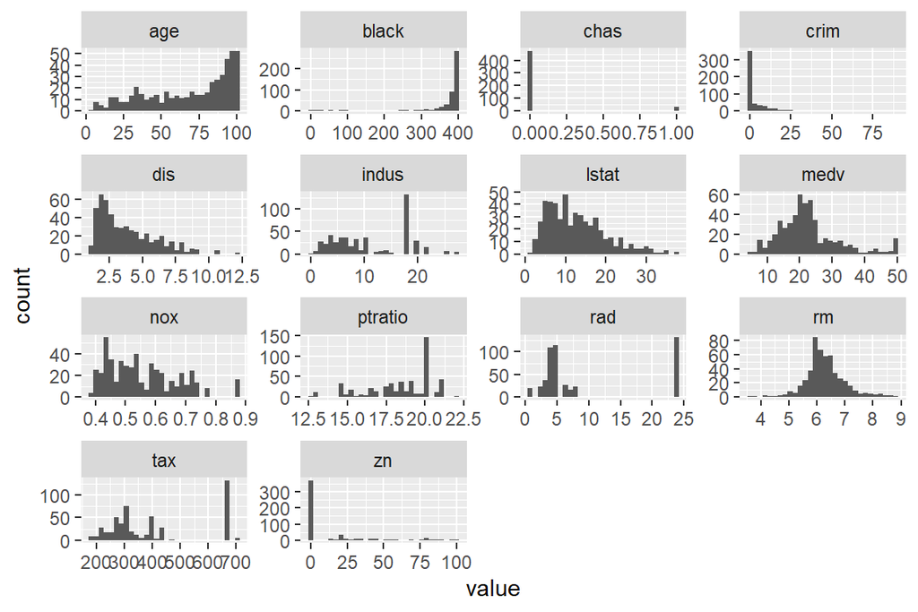

```r
#summaries graphically
Boston %>%
gather(key = "var", value = "value") %>%
ggplot(aes(x = value)) +
geom_histogram() +
facet_wrap(~ var, scales = "free")
```

The median of proportion of owned-occupied (age) units build prior to 1940 is 77.5 so the housing stock is fairly old overall. The median value of owner-occupied homes in $1000s (medv) histogram shows us that there’s a sudden drop of amount of high priced houses after roughly 25k usd. The average number of rooms per dwelling looks like it’s a bit right-skewed and suburb housing markets seem to cater those who need around 6 rooms.

Let’s use corrplot library to graphically to also show the correlation coefficients between variables:

```r
library(corrplot)
round(cor(Boston),1)
```

```
##         crim   zn indus chas  nox   rm  age  dis  rad  tax ptratio black lstat
## crim     1.0 -0.2   0.4 -0.1  0.4 -0.2  0.4 -0.4  0.6  0.6     0.3  -0.4   0.5
## zn      -0.2  1.0  -0.5  0.0 -0.5  0.3 -0.6  0.7 -0.3 -0.3    -0.4   0.2  -0.4
## indus    0.4 -0.5   1.0  0.1  0.8 -0.4  0.6 -0.7  0.6  0.7     0.4  -0.4   0.6
## chas    -0.1  0.0   0.1  1.0  0.1  0.1  0.1 -0.1  0.0  0.0    -0.1   0.0  -0.1
## nox      0.4 -0.5   0.8  0.1  1.0 -0.3  0.7 -0.8  0.6  0.7     0.2  -0.4   0.6
## rm      -0.2  0.3  -0.4  0.1 -0.3  1.0 -0.2  0.2 -0.2 -0.3    -0.4   0.1  -0.6
## age      0.4 -0.6   0.6  0.1  0.7 -0.2  1.0 -0.7  0.5  0.5     0.3  -0.3   0.6
## dis     -0.4  0.7  -0.7 -0.1 -0.8  0.2 -0.7  1.0 -0.5 -0.5    -0.2   0.3  -0.5
## rad      0.6 -0.3   0.6  0.0  0.6 -0.2  0.5 -0.5  1.0  0.9     0.5  -0.4   0.5
## tax      0.6 -0.3   0.7  0.0  0.7 -0.3  0.5 -0.5  0.9  1.0     0.5  -0.4   0.5
## ptratio  0.3 -0.4   0.4 -0.1  0.2 -0.4  0.3 -0.2  0.5  0.5     1.0  -0.2   0.4
## black   -0.4  0.2  -0.4  0.0 -0.4  0.1 -0.3  0.3 -0.4 -0.4    -0.2   1.0  -0.4
## lstat    0.5 -0.4   0.6 -0.1  0.6 -0.6  0.6 -0.5  0.5  0.5     0.4  -0.4   1.0
## medv    -0.4  0.4  -0.5  0.2 -0.4  0.7 -0.4  0.2 -0.4 -0.5    -0.5   0.3  -0.7
##         medv
## crim    -0.4
## zn       0.4
## indus   -0.5
## chas     0.2
## nox     -0.4
## rm       0.7
## age     -0.4
## dis      0.2
## rad     -0.4
## tax     -0.5
## ptratio -0.5
## black    0.3
## lstat   -0.7
## medv     1.0
```

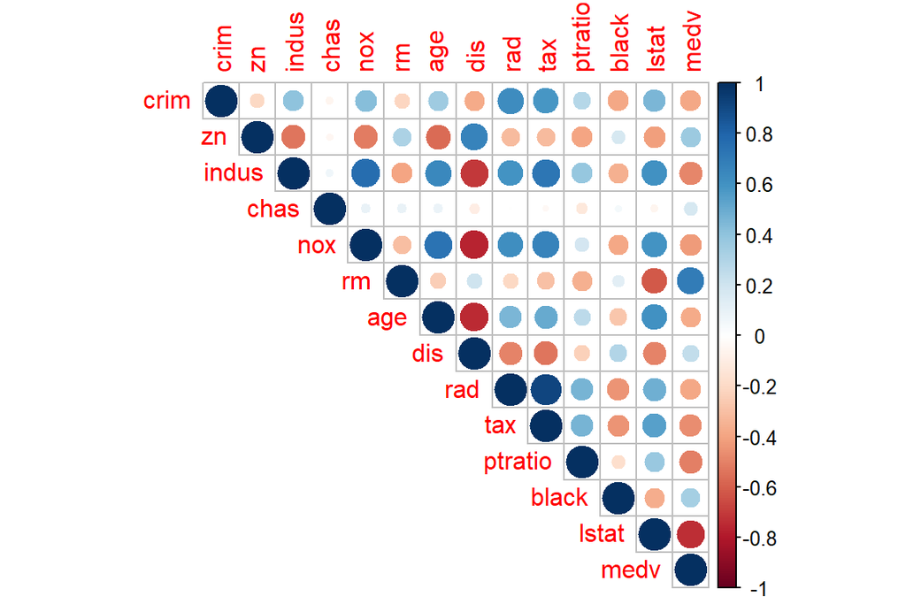

```r
corrplot(cor(Boston),
         type="upper",
         )
```

Correlation coefficients give us values between -1 and 1. Positive correlation (0 to 1) means that when one variable changes, the other variable changes to same direction. Negative correlation (-1 to 0) means that the other variable goes to the opposite direction. 0 valua means no correlation.

From correlations we can see some self-evident correlations such as the strong negative correlation of nitrogen oxides concentration (nox) and weighted mean distances to Five Boston employment centres (dis). The longer the distance from high traffic zones the less nitrogen oxides are in the area. Obviously the (nox) correlates strongly (and positively) with proportion of non-retail business acres per town (indus). Factories typically produce more emissions so more nitrogen oxides in those suburbs. Interestingly there’s also a strong positive correlation between accessibility to radial highways (rad) and full-value property tax-rate per $10000 (tax).

Biggest correlations to crime rate are interestingly the before-mentioned full-value property-tax rate per $10000 (tax) and accessibility to radial highways (rad). This is all speculation but this might be due to how crimes could be more likely to be reported in richer areas than in poorer suburbs - how this data was gained is interesting nonetheless.

### 2. Standardizing the dataset

As seen earlier from the box plots the variables get pretty different values so in age, black and tax variables compared to the rest so it’d wise to scale the whole dataset. Function scale() scales the dataset like this:

$$scaled(x) = \frac{x - mean(x)}{
sd(x)}$$

```r
# center and standardize variables
boston_scaled <- scale(Boston)

# summaries of the scaled variables
summary(boston_scaled)
```

```
##       crim                 zn               indus              chas
##  Min.   :-0.419367   Min.   :-0.48724   Min.   :-1.5563   Min.   :-0.2723
##  1st Qu.:-0.410563   1st Qu.:-0.48724   1st Qu.:-0.8668   1st Qu.:-0.2723
##  Median :-0.390280   Median :-0.48724   Median :-0.2109   Median :-0.2723
##  Mean   : 0.000000   Mean   : 0.00000   Mean   : 0.0000   Mean   : 0.0000
##  3rd Qu.: 0.007389   3rd Qu.: 0.04872   3rd Qu.: 1.0150   3rd Qu.:-0.2723
##  Max.   : 9.924110   Max.   : 3.80047   Max.   : 2.4202   Max.   : 3.6648
##       nox                rm               age               dis
##  Min.   :-1.4644   Min.   :-3.8764   Min.   :-2.3331   Min.   :-1.2658
##  1st Qu.:-0.9121   1st Qu.:-0.5681   1st Qu.:-0.8366   1st Qu.:-0.8049
##  Median :-0.1441   Median :-0.1084   Median : 0.3171   Median :-0.2790
##  Mean   : 0.0000   Mean   : 0.0000   Mean   : 0.0000   Mean   : 0.0000
##  3rd Qu.: 0.5981   3rd Qu.: 0.4823   3rd Qu.: 0.9059   3rd Qu.: 0.6617
##  Max.   : 2.7296   Max.   : 3.5515   Max.   : 1.1164   Max.   : 3.9566
##       rad               tax             ptratio            black
##  Min.   :-0.9819   Min.   :-1.3127   Min.   :-2.7047   Min.   :-3.9033
##  1st Qu.:-0.6373   1st Qu.:-0.7668   1st Qu.:-0.4876   1st Qu.: 0.2049
##  Median :-0.5225   Median :-0.4642   Median : 0.2746   Median : 0.3808
##  Mean   : 0.0000   Mean   : 0.0000   Mean   : 0.0000   Mean   : 0.0000
##  3rd Qu.: 1.6596   3rd Qu.: 1.5294   3rd Qu.: 0.8058   3rd Qu.: 0.4332
##  Max.   : 1.6596   Max.   : 1.7964   Max.   : 1.6372   Max.   : 0.4406
##      lstat              medv
##  Min.   :-1.5296   Min.   :-1.9063
##  1st Qu.:-0.7986   1st Qu.:-0.5989
##  Median :-0.1811   Median :-0.1449
##  Mean   : 0.0000   Mean   : 0.0000
##  3rd Qu.: 0.6024   3rd Qu.: 0.2683
##  Max.   : 3.5453   Max.   : 2.9865
```

```r
# change the object to data frame
boston_scaled <- as.data.frame(boston_scaled)
```

Every variable now has a mean of 0 as seen from the summary.

#### Creation of categorical variable

Let’s make a categorical variable of the crime rate in Boston by first creating a quantile vector and then creating the actual variable with labes “low”, “med_low”, “med_high” and “high”. After that we remove the original crim variable from the data frame and add the categorical value.

```r
# Work with the exercise in this chunk, step-by-step. Fix the R code!
# Boston and boston_scaled are available

# summary of the scaled crime rate
summary(boston_scaled$crim)
```

```
##      Min.   1st Qu.    Median      Mean   3rd Qu.      Max.
## -0.419367 -0.410563 -0.390280  0.000000  0.007389  9.924110
```

```r
# create a quantile vector of crim and print it
bins <- quantile(boston_scaled$crim)
bins
```

```
##           0%          25%          50%          75%         100%
## -0.419366929 -0.410563278 -0.390280295  0.007389247  9.924109610
```

```r
# create a categorical variable 'crime'
crime <- cut(boston_scaled$crim, breaks = bins, labels = c("low", "med_low", "med_high", "high"), include.lowest = TRUE)

# look at the table of the new factor crime


# remove original crim from the dataset
boston_scaled <- dplyr::select(boston_scaled, -crim)

# add the new categorical value to scaled data
boston_scaled <- data.frame(boston_scaled, crime)

summary(boston_scaled)
```

```
##        zn               indus              chas              nox
##  Min.   :-0.48724   Min.   :-1.5563   Min.   :-0.2723   Min.   :-1.4644
##  1st Qu.:-0.48724   1st Qu.:-0.8668   1st Qu.:-0.2723   1st Qu.:-0.9121
##  Median :-0.48724   Median :-0.2109   Median :-0.2723   Median :-0.1441
##  Mean   : 0.00000   Mean   : 0.0000   Mean   : 0.0000   Mean   : 0.0000
##  3rd Qu.: 0.04872   3rd Qu.: 1.0150   3rd Qu.:-0.2723   3rd Qu.: 0.5981
##  Max.   : 3.80047   Max.   : 2.4202   Max.   : 3.6648   Max.   : 2.7296
##        rm               age               dis               rad
##  Min.   :-3.8764   Min.   :-2.3331   Min.   :-1.2658   Min.   :-0.9819
##  1st Qu.:-0.5681   1st Qu.:-0.8366   1st Qu.:-0.8049   1st Qu.:-0.6373
##  Median :-0.1084   Median : 0.3171   Median :-0.2790   Median :-0.5225
##  Mean   : 0.0000   Mean   : 0.0000   Mean   : 0.0000   Mean   : 0.0000
##  3rd Qu.: 0.4823   3rd Qu.: 0.9059   3rd Qu.: 0.6617   3rd Qu.: 1.6596
##  Max.   : 3.5515   Max.   : 1.1164   Max.   : 3.9566   Max.   : 1.6596
##       tax             ptratio            black             lstat
##  Min.   :-1.3127   Min.   :-2.7047   Min.   :-3.9033   Min.   :-1.5296
##  1st Qu.:-0.7668   1st Qu.:-0.4876   1st Qu.: 0.2049   1st Qu.:-0.7986
##  Median :-0.4642   Median : 0.2746   Median : 0.3808   Median :-0.1811
##  Mean   : 0.0000   Mean   : 0.0000   Mean   : 0.0000   Mean   : 0.0000
##  3rd Qu.: 1.5294   3rd Qu.: 0.8058   3rd Qu.: 0.4332   3rd Qu.: 0.6024
##  Max.   : 1.7964   Max.   : 1.6372   Max.   : 0.4406   Max.   : 3.5453
##       medv              crime
##  Min.   :-1.9063   low     :127
##  1st Qu.:-0.5989   med_low :126
##  Median :-0.1449   med_high:126
##  Mean   : 0.0000   high    :127
##  3rd Qu.: 0.2683
##  Max.   : 2.9865
```

```r
str(boston_scaled)
```

```
## 'data.frame':    506 obs. of  14 variables:
##  $ zn     : num  0.285 -0.487 -0.487 -0.487 -0.487 ...
##  $ indus  : num  -1.287 -0.593 -0.593 -1.306 -1.306 ...
##  $ chas   : num  -0.272 -0.272 -0.272 -0.272 -0.272 ...
##  $ nox    : num  -0.144 -0.74 -0.74 -0.834 -0.834 ...
##  $ rm     : num  0.413 0.194 1.281 1.015 1.227 ...
##  $ age    : num  -0.12 0.367 -0.266 -0.809 -0.511 ...
##  $ dis    : num  0.14 0.557 0.557 1.077 1.077 ...
##  $ rad    : num  -0.982 -0.867 -0.867 -0.752 -0.752 ...
##  $ tax    : num  -0.666 -0.986 -0.986 -1.105 -1.105 ...
##  $ ptratio: num  -1.458 -0.303 -0.303 0.113 0.113 ...
##  $ black  : num  0.441 0.441 0.396 0.416 0.441 ...
##  $ lstat  : num  -1.074 -0.492 -1.208 -1.36 -1.025 ...
##  $ medv   : num  0.16 -0.101 1.323 1.182 1.486 ...
##  $ crime  : Factor w/ 4 levels "low","med_low",..: 1 1 1 1 1 1 2 2 2 2 ...
```

As seen from the summary there’s a new Factor variable “crime” that has 126-127 counts in each category.

#### Creation of data and training set

We’ll divide the dataset to train and test sets in which 80% of the data belongs to the train set. The divide is done randomly and we’ll save the test sets correct crime variables to correct_classes.

```r
# number of rows in the Boston dataset
n <- nrow(boston_scaled)

# choose randomly 80% of the rows
ind <- sample(n,  size = n * 0.8)

# create train set
train <- boston_scaled[ind,]

# create test set
test <- boston_scaled[-ind,]

# save the correct classes from test data
correct_classes <- test$crime

# remove the crime variable from test data
test <- dplyr::select(test, -crime)
```

### 3. Linear Discrimant Analysis

Linear Discrimant Analysis (LDA) is a classification method that is used for modelling differences in groups i.e. separating two or more classes. Below we have fitted the dataset to a LDA model and drawn the LDA model. In this case we want to see how the numerous variables affect crime rate.

```r
# linear discriminant analysis
lda.fit <- lda(crime ~ ., data = train)

# print the lda.fit object
lda.fit
```

```
## Call:
## lda(crime ~ ., data = train)
##
## Prior probabilities of groups:
##       low   med_low  med_high      high
## 0.2574257 0.2549505 0.2326733 0.2549505
##
## Group means:
##                   zn      indus         chas        nox         rm        age
## low       0.95388511 -0.9130431 -0.083045403 -0.8748023  0.4362402 -0.8669191
## med_low  -0.06554563 -0.3312946 -0.004759149 -0.5730592 -0.1198756 -0.3514998
## med_high -0.38506488  0.2527982  0.104627338  0.4495445  0.1538831  0.4387991
## high     -0.48724019  1.0170891 -0.081207697  1.0773337 -0.3506770  0.8039385
##                 dis        rad        tax     ptratio       black        lstat
## low       0.8958044 -0.6925458 -0.7653338 -0.41160875  0.37943417 -0.773369424
## med_low   0.3643390 -0.5458997 -0.4875436 -0.05435218  0.30981493 -0.172074053
## med_high -0.3842157 -0.4284078 -0.2881045 -0.23694841  0.06851438 -0.008279871
## high     -0.8307854  1.6384176  1.5142626  0.78111358 -0.76575786  0.861780021
##                  medv
## low       0.534332222
## med_low   0.002450063
## med_high  0.186825928
## high     -0.723189915
##
## Coefficients of linear discriminants:
##                 LD1         LD2         LD3
## zn       0.12100571  0.58061216 -1.03554317
## indus    0.04474313 -0.29288666  0.12579799
## chas    -0.10623797  0.01621679  0.16676097
## nox      0.33515532 -0.91112186 -1.25604974
## rm      -0.10332309 -0.15293821 -0.22201182
## age      0.27459735 -0.34157657 -0.17699390
## dis     -0.05520170 -0.36507355  0.06475082
## rad      3.42820053  1.12544928 -0.25349122
## tax      0.03016265 -0.16418783  0.70178672
## ptratio  0.09328445 -0.07606505 -0.31123728
## black   -0.08379630  0.03744263  0.09793901
## lstat    0.23678022 -0.20767463  0.37059448
## medv     0.17220465 -0.49616465 -0.19167126
##
## Proportion of trace:
##    LD1    LD2    LD3
## 0.9540 0.0343 0.0117
```

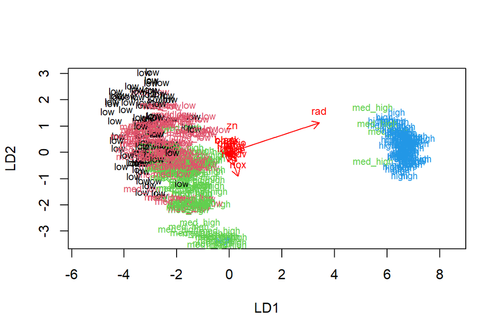

```r
# the function for lda biplot arrows
lda.arrows <- function(x, myscale = 1, arrow_heads = 0.1, color = "red", tex = 0.75, choices = c(1,2)){
  heads <- coef(x)
  arrows(x0 = 0, y0 = 0,
         x1 = myscale * heads[,choices[1]],
         y1 = myscale * heads[,choices[2]], col=color, length = arrow_heads)
  text(myscale * heads[,choices], labels = row.names(heads),
       cex = tex, col=color, pos=3)
}

# target classes as numeric
classes <- as.numeric(train$crime)

# plot the lda results
plot(lda.fit, dimen = 2, col = classes, pch = classes)
lda.arrows(lda.fit, myscale = 1)
```

```r
# predict classes with test data
lda.pred <- predict(lda.fit, newdata = test)
# cross tabulate the results
table(correct = correct_classes, predicted = lda.pred$class)
```

```
##           predicted
## correct    low med_low med_high high
##   low       16       7        0    0
##   med_low    4      16        3    0
##   med_high   0      17       13    2
##   high       0       0        0   24
```

### 4. K-means clustering

Let’s reload the Boston dataset and calculate distances between observations with euclidean and manhattan methods. Euclidean distance is linear distance between two data points in a plane. Manhattan distance is the sum of absolute differences between points in all dimensions, in other words it can be viewed as a zig-zagging ‘city block distance’.

```r
# loading data and standardizing it
data("Boston")
newboston <- scale(Boston)
newboston <- as.data.frame(newboston)

#calculating distances with euclidean and manhattan methods
dist_euc <- dist(newboston, method = "euclidean")
dist_man <- dist(newboston, method = "manhattan")
summary(dist_euc)
```

```
##    Min. 1st Qu.  Median    Mean 3rd Qu.    Max.
##  0.1343  3.4625  4.8241  4.9111  6.1863 14.3970
```

```r
summary(dist_man)
```

```
##    Min. 1st Qu.  Median    Mean 3rd Qu.    Max.
##  0.2662  8.4832 12.6090 13.5488 17.7568 48.8618
```

And the lets run a k-mean algorithm lets investigate.

[figure not shown]

```r
kmean <- kmeans(newboston, centers=4)
pairs(newboston, col = kmean$cluster)
```

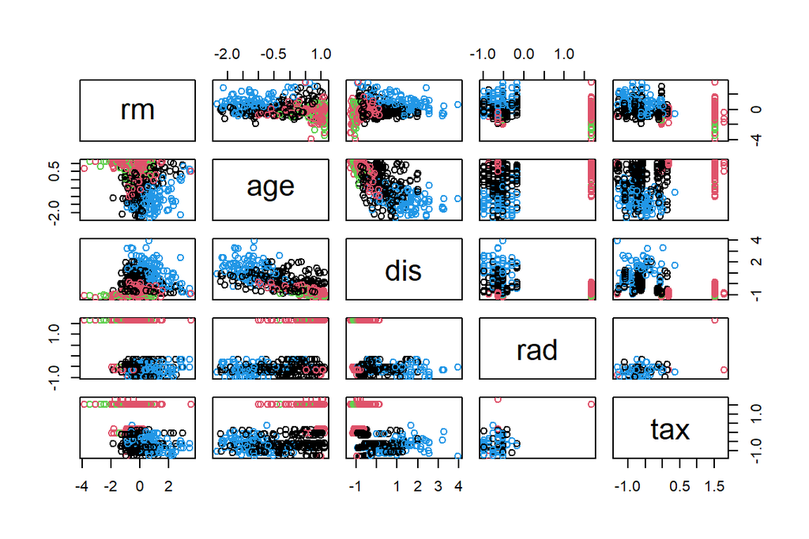

```r
pairs(newboston[6:10], col = kmean$cluster)
```

With this many variables pairs is a bit of a mess but we could show it in smaller ‘doses’ by comparing smaller amounts of columns at once. Let’s determine the optimal amount of clusters:

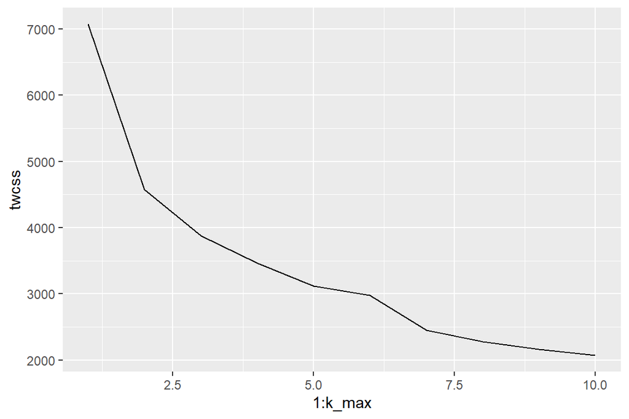

```r
# determine the number of clusters
k_max <- 10

# calculate the total within sum of squares
twcss <- sapply(1:k_max, function(k){kmeans(newboston, k)$tot.withinss})

# visualize the results
qplot(x = 1:k_max, y = twcss, geom = 'line')
```

The twcss value drops radically when clusters go to 2 so this should be the optimal amount of clusters. Let’s plot pairs again with 2 centers.

[figure not shown]

```r
kmean2 <- kmeans(newboston, centers=2)
pairs(newboston, col = kmean2$cluster)
```

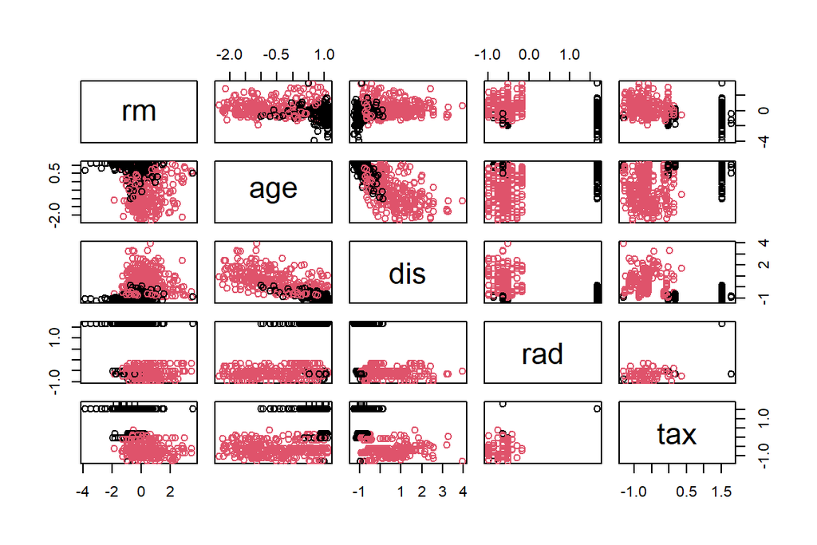

```r
pairs(newboston[6:10], col = kmean2$cluster)
```

The clusters are much more recognizable now and and less overlapping.

## Data wrangling

This time data wrangling exercise was prepwork for next week’s assignemt. As usual you can find the create_human.R script from my repo’s [data folder](https://github.com/jmlankinen/IODS-project/tree/master/data).